# ADPS 2025Z — Laboratorium 3 (rozwiązania)

Imię i Nazwisko

# Zadanie 1 (1 pkt)

## Treść zadania

Plik tempciala.txt zawiera zarejestrowane wartości tętna oraz temperatury ciała dla 65 mężczyzn (płeć = 1) i 65 kobiet (płeć = 2).

Osobno dla mężczyzn i kobiet:

- wyestymuj wartość średnią i odchylenie standardowe temperatury,
- zweryfikuj przy poziomie istotności $\alpha = 0.05$ hipotezę, że średnia temperatura jest równa 36.6 $^\circ$C wobec hipotezy alternatywnej, że średnia temperatura jest inna, przyjmując, że temperatury mają rozkład normalny, a wariancja rozkładu jest nieznana.

## Rozwiązanie

```
sr_temp_m <- mean(tc$temperatura[tc$płeć == 1]); sr_temp_m
```

```
[1] 36.72615
```

```
t.test(tc_k, mu = mi_0, alternative = "two.sided") -> test_k; test_k
```

```
    One Sample t-test

data:  tc_k
t = 5.6497, df = 64, p-value = 3.985e-07
alternative hypothesis: true mean is not equal to 36.6
95 percent confidence interval:
 36.78696 36.99150
sample estimates:
mean of x
 36.88923
```

Hipotezę zerową odrzucamy bo p-value jest mniejsza od lambda

# Zadanie 2 (1 pkt)

## Treść zadania

W tabeli przedstawionej poniżej zawarto dane dot. liczby samobójstw w Stanach Zjednoczonych w 1970 roku z podziałem na poszczególne miesiące.

| Miesiąc | Liczba samobójstw | Liczba dni |
| --- | --- | --- |
| Styczeń | 1867 | 31 |
| Luty | 1789 | 28 |
| Marzec | 1944 | 31 |
| Kwiecień | 2094 | 30 |
| Maj | 2097 | 31 |
| Czerwiec | 1981 | 30 |
| Lipiec | 1887 | 31 |
| Sierpień | 2024 | 31 |
| Wrzesień | 1928 | 30 |
| Październik | 2032 | 31 |
| Listopad | 1978 | 30 |
| Grudzień | 1859 | 31 |

Zweryfikuj przy poziomie istotności $\alpha = 0.05$ czy zamieszczone w niej dane świadczą o stałej intensywności badanego zjawiska, czy raczej wskazują na sezonową zmienność liczby samobójstw. Przyjmij, że w przypadku stałej intensywności liczby samobójstw, liczba samobójstw w danym miesiącu jest proporcjonalna do liczby dni w tym miesiącu.

## Rozwiązanie

```
chisq.test(x = ni_i, p = p_i)
```

```
    Chi-squared test for given probabilities

data:  ni_i
X-squared = 47.365, df = 11, p-value = 1.852e-06
```

T > c i p < alfa - odrzucamy H0, sezonowość jest istotna.

# Zadanie 3 (1 pkt)

## Treść zadania

Dla wybranej spółki notowanej na GPW wczytaj dane ze strony stooq.pl, a następnie

- oblicz wartości procentowych zmian najniższych cen w poszczególnych dniach w ciągu ostatniego roku, wykreśl ich histogram i narysuj funkcję gęstości prawdopodobieństwa rozkładu normalnego o parametrach wyestymowanych na podstawie ich wartości,
- stosując rózne testy omawiane w przykładach zweryfikuj przy poziomie istotności $\alpha = 0.05$ hipotezę, że procentowe zmiany najniższych cen w poszczególnych dniach w ciągu ostatniego roku mają rozkład normalny.

## Rozwiązanie

```
# https://stooq.pl/q/d/l/?s=kgh&i=d
Ticket = 'KGH'
webLink = paste0('https://stooq.pl/q/d/l/?s=', Ticket, '&i=d')
fileName = paste0(Ticket, '.csv')
if(!file.exists(fileName)) {
download.file(webLink, fileName)
}
```

```
df_KGH = read.csv('KGH.csv')
df_KGH$Data = as.Date(df_KGH$Data)
df_KGH$Najnizszy_zm = with(df_KGH, c(NA, 100*diff(Najnizszy)/Najnizszy[-length(Najnizszy)]))
df_KGH_1rok = df_KGH[which(df_KGH$Data >= '2024-12-12' & df_KGH$Data <= Sys.Date()),]
m = mean(df_KGH_1rok$Najnizszy_zm, na.rm = T)
s = sd(df_KGH_1rok$Najnizszy_zm, na.rm = T)
hist(df_KGH_1rok$Najnizszy_zm, breaks = 50, prob = T,
xlab = 'Zmiana najniższych cen [%]',
ylab = 'Częstość występowania',
main = paste('Histogram procentowych zmian kursu', 'KGHM'))
grid()
```

```
min_c = min(df_KGH_1rok$Najnizszy_zm, na.rm = T)
max_c = max(df_KGH_1rok$Najnizszy_zm, na.rm = T)
curve(dnorm(x, mean = m, sd = s), add = TRUE, col = 'red', from = min_c, to = max_c)
```

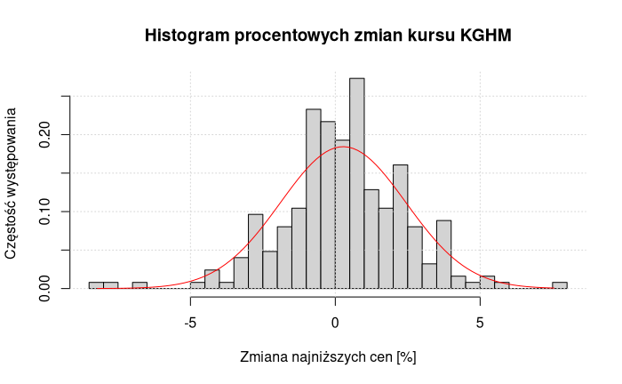

```
x = df_KGH_1rok$Najnizszy_zm
mean(x)
```

```
[1] 0.2729645
```

```
sd(x)
```

```
[1] 2.164072
```

```
length(x)
```

```
[1] 249
```

```
#Test Kołmogorowa-Smirnowa (parametry z próby)
ks.test(x, "pnorm", mean = mean(x), sd = sd(x))
```

```
    Asymptotic one-sample Kolmogorov-Smirnov test

data:  x
D = 0.064251, p-value = 0.2554
alternative hypothesis: two-sided
```

```
#Test Shapiro-Wilka
shapiro.test(x)
```

```
    Shapiro-Wilk normality test

data:  x
W = 0.97944, p-value = 0.001134
```

```
#Test Jarque-Bera
library(moments)
jarque.test(x)
```

```
    Jarque-Bera Normality Test

data:  x
JB = 32.639, p-value = 8.176e-08
alternative hypothesis: greater
```

```
#Test skośności i kurtozy
agostino.test(x)
```

```
    D'Agostino skewness test

data:  x
skew = -0.34285, z = -2.21378, p-value = 0.02684
alternative hypothesis: data have a skewness
```

```
anscombe.test(x)
```

```
    Anscombe-Glynn kurtosis test

data:  x
kurt = 4.6358, z = 3.4587, p-value = 0.0005428
alternative hypothesis: kurtosis is not equal to 3
```

Przy poziomie istotności α = 0.05 test Shapiro-Wilka oraz test Jarque-Bera dały p-wartości mniejsze od 0.05, co prowadzi do odrzucenia hipotezy zerowej o normalności rozkładu procentowych zmian najniższych cen akcji KGHM w ciągu ostatniego roku. Oznacza to, że rozkład badanych stóp zwrotu istotnie odbiega od rozkładu normalnego.

# Zadanie 4 (1 pkt)

## Treść zadania

W pliku lozyska.txt podane są czasy (w milionach cykli) pracy (do momentu uszkodzenia) łożysk wykonywanych z dwóch różnych materiałów.

- Przeprowadź test braku różnicy między czasami pracy łożysk wykonanych z różnych materiałów, zakładając że czas pracy do momentu uszkodzenia opisuje się rozkładem normalnym, bez zakładania róności wariancji. Przyjmij poziom istotności $\alpha = 0.05$.
- Przeprowadź analogiczny test, bez zakładania normalności rozkładów.
- **(dla chętnych)** Oszacuj prawdopodobieństwo tego, że łożysko wykonane z pierwszego materiału będzie pracowało dłużej niż łożysko wykonane z materiału drugiego.

## Rozwiązanie

```
dane = read.csv('lozyska.txt')
x = dane$X.Typ.I.
y = dane$X.Typ.II.

t.test(x, y, alternative = "two.sided", var.equal = FALSE)
```

```
    Welch Two Sample t-test

data:  x and y
t = 2.0723, df = 16.665, p-value = 0.05408
alternative hypothesis: true difference in means is not equal to 0
95 percent confidence interval:
 -0.07752643  7.96352643
sample estimates:
mean of x mean of y
   10.693     6.750
```

p-value ≥ 0.05

Brak podstaw do odrzucenia hipotezy zerowej o równości średnich czasów pracy łożysk wykonanych z dwóch różnych materiałów.

```
wilcox.test(x, y, alternative = "two.sided")
```

```
    Wilcoxon rank sum exact test

data:  x and y
W = 75, p-value = 0.06301
alternative hypothesis: true location shift is not equal to 0
```

p-value ≥ 0.05:

Brak podstaw do odrzucenia hipotezy zerowej o braku różnic między czasami pracy łożysk wykonanych z dwóch różnych materiałów.

```
#Obliczenie prawdopodobieństwa
test = wilcox.test(x, y, exact = TRUE)

P_hat = as.numeric(test$statistic) / (length(x) * length(y))
P_hat
```

```
[1] 0.75
```

Na podstawie statystyki testu Manna–Whitneya W=75 W=75 oszacowano prawdopodobieństwo, że losowo wybrane łożysko wykonane z pierwszego materiału będzie pracowało dłużej niż łożysko wykonane z drugiego materiału. Otrzymano wartość P^(X>Y)=0.75 P ^ (X>Y)=0.75. Oznacza to, że w około 75% przypadków czas pracy łożyska z materiału I jest dłuższy niż czas pracy łożyska z materiału II. ***

# Zadanie 5 (1 pkt)

## Treść zadania

Korzystając z danych zawartych na stronie pl.fcstats.com zweryfikuj hipotezę o niezależności wyników (zwycięstw, remisów i porażek) gospodarzy od kraju, w którym prowadzone są rozgrywki piłkarskie. Przyjmij poziom istotności $\alpha = 0.05$.

- Testy przeprowadź na podstawie danych dotyczących lig:
  - niemieckiej – Bundesliga (Liga niemiecka),
  - polskiej – Ekstraklasa (Liga polska),
  - angielskiej – Premier League (Liga angielska),
  - hiszpańskiej – LaLiga (Liga hiszpańska).
- Dane znajdują się w zakładce Porównanie lig -> Zwycięzcy meczów, w kolumnach (bez znaku [%]):
  - 1 – zwycięstwa gospodarzy, np. dla ligi niemieckiej (Bundesliga) 125,
  - x – remisy, np. dla ligi niemieckiej 86,
  - 2 – porażki gospodarzy, np. dla ligi niemieckiej 95.

## Rozwiązanie

DE 1: 125; 2: 86; 3: 95 PL 1: 108; 2: 65; 3: 67 ANG 1: 193; 2: 96; 3: 91 ESP 1: 194; 2: 95; 3: 91

H0: wynik meczu gospodarzy jest niezależny od kraju (ligi) H1: wynik meczu gospodarzy zalez˙y od kraju (ligi)

[output not shown]